# Applied microeconometrics

Week 2 - Linear regression (OLS) and bootstrapping

Josh Merfeld

KDI School

September 23, 2024

# Introduction

## What are we doing today?

- This week we will review linear regression (OLS) and its assumptions
  - We will also discuss how to interpret the results of a regression
- Some of this will be review, but there will be some new stuff, too
  - For example, we will discuss bootstrapping on Thursday

## What are we doing today?

- I will be going through some econometric theory this week
- But we will also be using some data throughout the week
  - This data comes from the [World Development Indicators](https://databank.worldbank.org/source/world-development-indicators) database
  - I have uploaded the csv file to this week’s GitHub folder

# Fitting lines

## Fitting lines to data

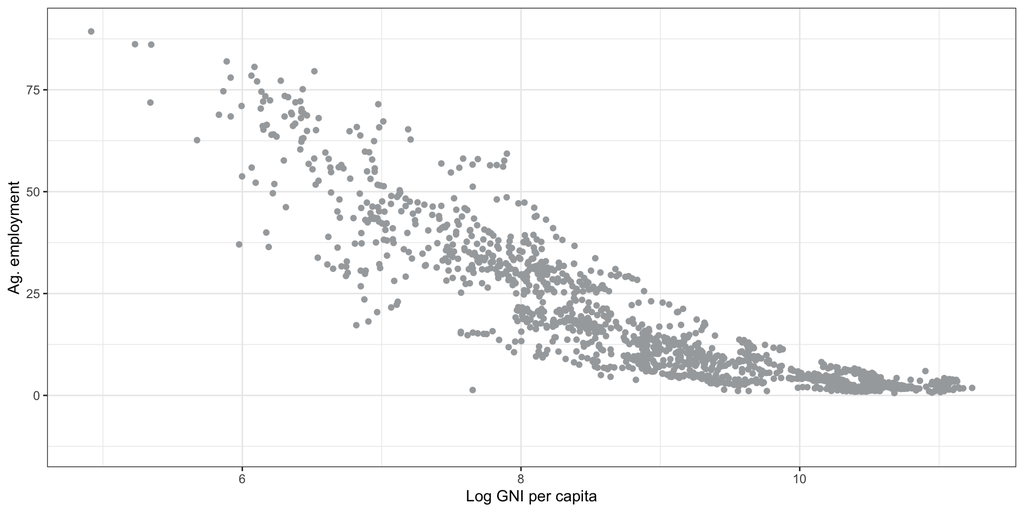

## Which line best fits the data?

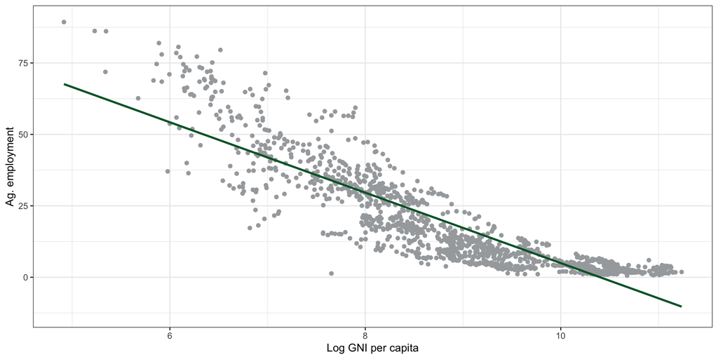

## Ordinary Least Squares (OLS)

- OLS is a method for fitting a line to data
  - It is the most common method for fitting lines to data
- You have an outcome, let’s call it $y_i$ (where $y$ is the outcome and $i$ is an individual)
- You also have a set of covariates, let’s call them $x_{ik}$ (where $k$ denotes different covariates)
- The relationship might look something like this, assuming linearity:
  $$\begin{gather}y_i = \beta_0 + \beta_1 x_{i,1} + \beta_2 x_{i,2} + \dots + \beta_k x_{i,k} + \epsilon_i \end{gather}$$

## Ordinary Least Squares (OLS)

- OLS is about finding the **average** relationship between $Y$ and a set of covariates, $X$
  - The fit will never be perfect, which is why we have $\epsilon_i$
  - $\epsilon_i$ is the error term and shows that individuals will deviate from the average relationship
  - For example, Bill Gates is a high-school drop out but is still a billionaire; this is deviation from an average relationship between education and income

## Minimizing the sum of squared errors

- In order to find a “line of best fit”, we need an objective function
  - We want to minimize the distance between the line and the data, but how do we define that distance?
- We can define the distance as the sum of squared errors (SSE)
  - The SSE is the sum of the squared difference between the actual value and the predicted value
  - The predicted value is the value on the line of best fit
- In other words:
  $$\begin{gather} \text{SSE} = \sum_{i=1}^n (y_i - \hat{y}_i)^2 \end{gather}$$

## Minimizing the sum of squared errors

$$\begin{gather} \text{SSE} = \sum_{i=1}^n (y_i - \hat{y}_i)^2 \end{gather}$$

- $\hat{y}_i$ is the predicted value of $y_i$ for individual $i$
- But how do we find $\hat{y}_i$?
  - We need to find the line of best fit
  - We need to find the values of $\beta_0, \beta_1, \dots, \beta_k$ that minimize the SSE.
- We can do this by noting that $\hat{y_i} = \hat{\beta_0} + \hat{\beta_1} x_{i,1} + \hat{\beta_2} x_{i,2} + \dots + \hat{\beta_k} x_{i,k}$:

$$\begin{gather} \text{SSE} = \sum_{i=1}^n (y_i - \beta_0 - \hat{\beta_1} x_{i,1} - \hat{\beta_2} x_{i,2} - \dots - \hat{\beta_k} x_{i,k})^2 \end{gather}$$

## In matrix form

- Let’s rewrite the equation in matrix form:
- $\mathbf{Y}$ is a vector of outcomes, $\mathbf{X}$ is a matrix of covariates, and $\boldsymbol{\beta}$ is a vector of coefficients:
  $$\begin{gather} \text{SSE} = (\mathbf{Y} - \mathbf{X} \boldsymbol{\beta})' (\mathbf{Y} - \mathbf{X} \boldsymbol{\beta}) \end{gather}$$
- It turns out that this becomes an optimization problem
- We know the $\mathbf{Y}$ and $\mathbf{X}$, so we want to minimize this with respect to $\boldsymbol{\beta}$:
  $$\begin{gather} \min_{\boldsymbol{\beta}} (\mathbf{Y} - \mathbf{X} \boldsymbol{\beta})' (\mathbf{Y} - \mathbf{X} \boldsymbol{\beta}) \end{gather}$$

## The solution

- We know the solution to this:
  $$\begin{gather} \hat{\boldsymbol{\beta}} = (\mathbf{X}' \mathbf{X})^{-1} \mathbf{X}' \mathbf{Y} \end{gather}$$
- Seer this formula into your brain!

# LLN and CLT

## A problem: uncertainty

- We have a solution, but we have a problem: uncertainty
  - We generally do not have the population, which means $\hat{\boldsymbol{\beta}}$ is just a sample estimate of the population parameters $\boldsymbol{\beta}$
  - Note the use of hats to denote sample estimates
- We need to know how uncertain we are about our estimates
  - We need to know how much $\hat{\boldsymbol{\beta}}$ will vary from sample to sample
  - Before we do this, we need to do a little bit of background on probability and statistics

## Two important theorems

- There are two important theorems that we need to know about
  - The Law of Large Numbers
  - The Central Limit Theorem
- Let’s go through these one at a time

## Law of Large Numbers (LLN)

- The LLN says that as the sample size increases, the sample mean will converge to the population mean
  - In other words, as $n \rightarrow \infty$, $\bar{x} \rightarrow \mu$
    - where $n$ is the sample size, $\bar{x}$ is the sample mean, $\mu$ is the true population mean
- You don’t have to take my word for this, though. Let’s see it in action.

## LLN as an example

Let’s create a “population” of 100,000 random numbers from a normal distribution with mean 0 and standard deviation 1

```r
# note that rnorm is a "random" number generator, so we need to set a seed to make sure we get the same results each time
set.seed(1304697)
# NOTE: just set the seed once, at the top of your script. Then run everything and you will get reproducible results
population <- rnorm(100000, mean = 0, sd = 1)

mean(population)
```

```
[1] -0.003674513
```

## LLN as an example

- So we know the true mean is $\mu = -0.0036745$
- Let’s see what happens as we take a sample of size 10:

```r
sample <- population[sample(1:length(population), 10, replace = FALSE)]

mean(sample)
```

```
[1] -0.07407166
```

- Let’s see what happens as we take a sample of size 100:

```r
sample <- population[sample(1:length(population), 100, replace = FALSE)]

mean(sample)
```

```
[1] -0.01106315
```

## Suppose we did this a bunch of times…

- Let’s say we took a sample of size 10, 100 times
  - We would get 100 different sample means
  - We can calculate how “far” each sample mean is from the true mean
  - We can do the same thing for a bunch of different sample sizes
- Let’s then plot the average mean squared error (MSE) for each sample size
  - The MSE is the average squared difference between the sample mean and the true mean
  - In other words, it is the average of $(\bar{x} - \mu)^2$

## The results

```r
sample <- c()
i <- 1
for (size in seq(from = 10, to = 500, by = 10)) {
  sample[[i]] <- vector(mode = "double", length = 100)
  for (j in 1:100){
    sample[[i]][j] <- (mean(population) - mean(population[sample(1:length(population), size, replace = FALSE)]))^2
  }
  i <- i + 1
}

means <- sapply(sample, mean)

ggplot() +
  geom_smooth(aes(x = seq(from = 10, to = 500, by = 10), y = means), se = FALSE, color = rgb(0, 99, 52, maxColorValue = 255)) +
  theme_bw() +
  labs(x = "Sample size", y = "Mean squared error")
```

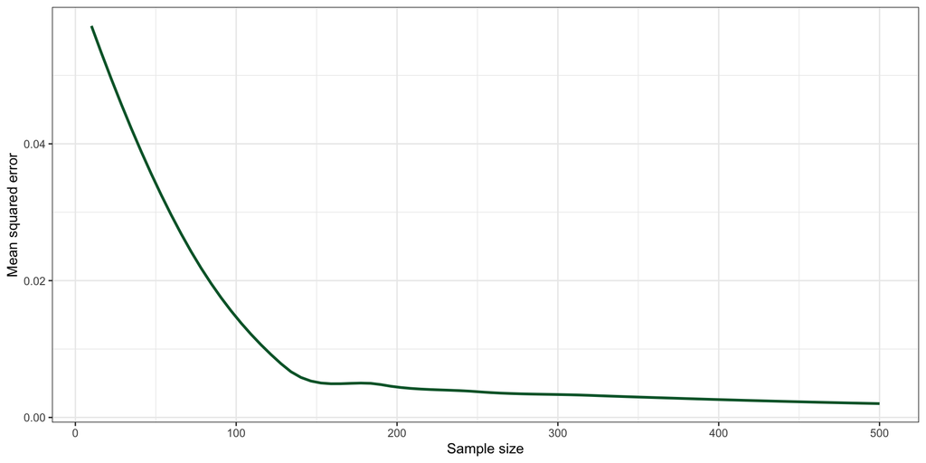

## The results

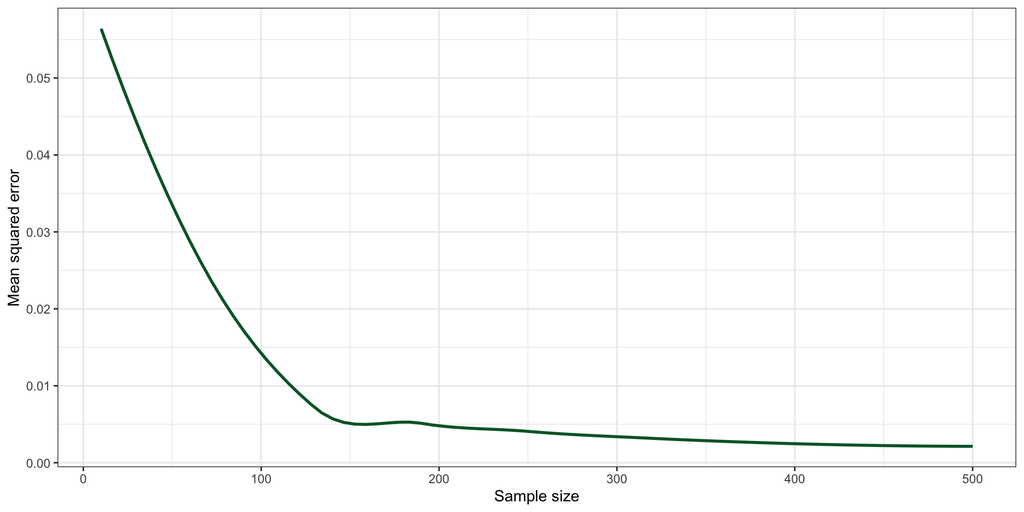

## Non-normal distributions

- This doesn’t just work with normal distributions
- Here’s an example with a more skewed distribution
- Let’s create a “population” of 100,000 random numbers from a gamma distribution with a shape ($k$) of 1 and a scale ($\theta$) of 2

```r
population2 <- rgamma(100000, shape = 1, scale = 2)
mean(population2)
```

```
[1] 1.994318
```

## The two populations

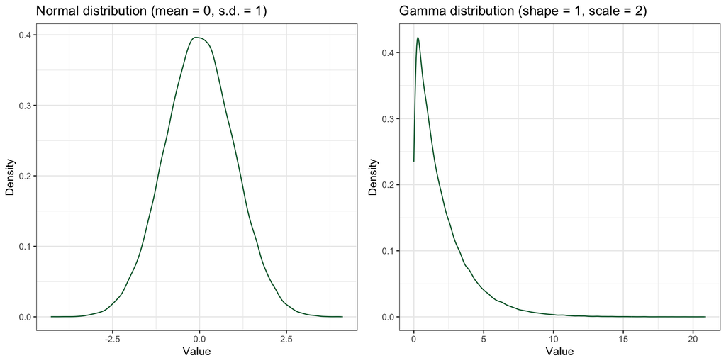

## The results for the gamma distribution

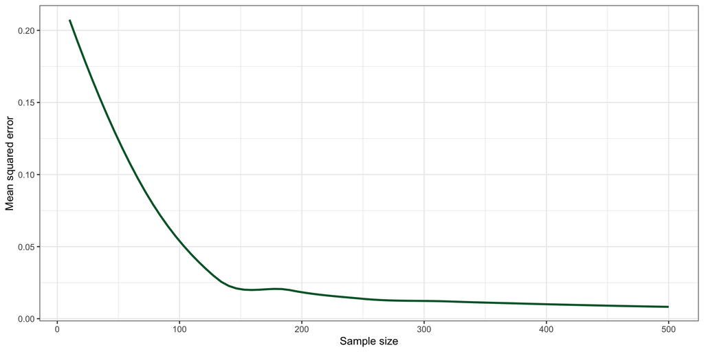

## The takeaway from the LLN

- The main takeaway from the LLN is that as the sample size increases, the sample mean will converge to the population mean
  - In other words, as $n \rightarrow \infty$, $\bar{x} \rightarrow \mu$
- This holds for many different distributions!
  - Note that it will approach the mean for a normal distribution more quickly than skewed distributions!
  - Something we will return to is that this also holds for the distribution of $\hat{\boldsymbol{\beta}}$

## The Central Limit Theorem

- The LLN is about the **mean**
  - The Central Limit Theorem (CLT) is about the **distribution**
- The CLT says that as the sample size increases, the distribution of the sample mean will converge to a normal distribution
  - In other words, as $n \rightarrow \infty$, $\bar{x} \sim N(\mu, \sqrt{\sigma^2/n})$
  - where $\mu$ is the true population mean and $\sigma^2$ is the true population variance

## The CLT, empirically

- We can do something similar to what we did with the LLN
  - Instead of looking at means, though, we will look at *distributions of the mean*
  - In other words, we will density functions of the sample means
- I am going to take a sample and find the mean
  - Then I’m going to do it again
  - And again
  - 1,000 times
- Then I will plot the density of the sample means, for four separate sample sizes (10, 50, 100, and 500)

## The CLT with four sample sizes: 10, 50, 100, and 500 and 1,000 replications

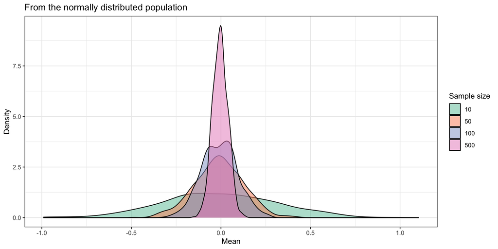

## The CLT with four sample sizes: 10, 50, 100, and 500 and 1,000 replications

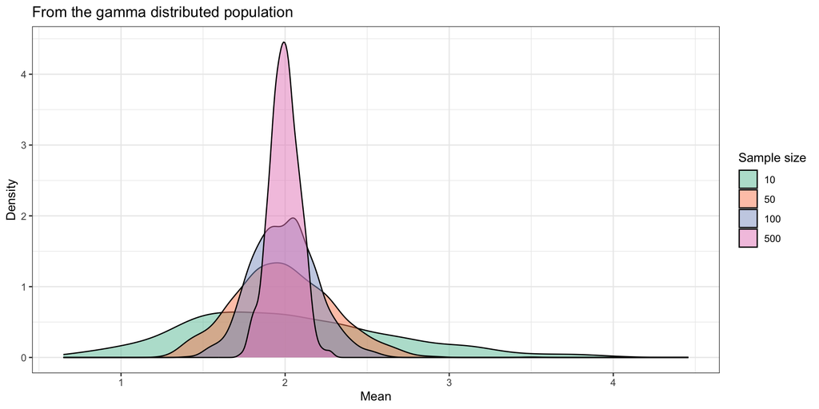

## The CLT lets us quantify uncertainty

- The key thing about the CLT is that the math behind us *lets us quantify the uncertainty!*
- For sample means, the CLT says that the standard error of the mean is:
  - $\sigma_{\bar{x}} = \frac{\sigma}{\sqrt{n}}$
    - where $\sigma$ is the population standard deviation and $n$ is the sample size
- Of course, we don’t know $\sigma$, but we can estimate it!

## The CLT lets us quantify uncertainty

- We can estimate $\sigma$ with $s$
  - $s$ is the sample standard deviation
  - So we can estimate the standard error of the mean as:
    - $SE_{\bar{x}} = \frac{s}{\sqrt{n}}$
- This “standard error of the mean” is the standard deviation of the distribution of the sample mean
  - That distribution is called the sampling distribution of the mean

# OLS Variance

## Uncertainty in OLS

- Let’s go back to our (population) regression equation:
  $$\begin{gather} \mathbf{Y} = \mathbf{X} \boldsymbol{\beta} + \boldsymbol{\epsilon} \end{gather}$$
- What drives uncertainty here?
  - The **error term**, $\boldsymbol{\epsilon}$
  - Note that an error term is a *population* parameter
  - The sample analog is the **residual**

## Uncertainty in OLS

- We can see that the error term is responsible for uncertainty by thinking about the deviation of estimated regression coefficients ($\hat{\boldsymbol{\beta}}$) from the true regression coefficients ($\boldsymbol{\beta}$)
  $$\begin{gather*} \boldsymbol{Y} = \boldsymbol{\beta} \mathbf{X} + \boldsymbol{\epsilon} \hspace{2cm} \hat{\boldsymbol{\beta}} = (\mathbf{X}' \mathbf{X})^{-1} \mathbf{X}' \boldsymbol{Y} \\
  \hat{\boldsymbol{\beta}} = (\mathbf{X}' \mathbf{X})^{-1} \mathbf{X}' (\boldsymbol{\beta} \mathbf{X} + \boldsymbol{\epsilon}) \\
  \hat{\boldsymbol{\beta}} = (\mathbf{X}' \mathbf{X})^{-1} \mathbf{X}'\boldsymbol{\beta} \mathbf{X} + (\mathbf{X}' \mathbf{X})^{-1} \mathbf{X}'\boldsymbol{\epsilon})\end{gather*}$$

$$\begin{gather} \hat{\boldsymbol{\beta}} = \boldsymbol{\beta} + (\mathbf{X}' \mathbf{X})^{-1} \mathbf{X}'\boldsymbol{\epsilon} \end{gather}$$

- $\beta$ is fixed, but $\epsilon$ is random
  - So $\hat{\boldsymbol{\beta}}$ is random, too
  - That randomness is driven by the error term, $\boldsymbol{\epsilon}$

## Variance of $\hat{\boldsymbol{\beta}}$

- Variance is about how much a random variable varies from its mean
  - It’s a second-order moment (i.e. squared deviation from the mean)
  - Note how we use expectations here, since we are talking about population parameters
  - Also note that this comes directly from the second part of the previous equation!

$$\begin{gather} Var(\hat{\boldsymbol{\beta}} | \boldsymbol{X}) = (\mathbf{X}' \mathbf{X})^{-1} \mathbf{X}'\mathbb{E}(\boldsymbol{\epsilon}'\boldsymbol{\epsilon}|\boldsymbol{X})\mathbf{X}(\mathbf{X}' \mathbf{X})^{-1} \end{gather}$$

- Well that doesn’t look very good, does it?
  - We can simplify this… with an assumption on $\mathbb{E}(\boldsymbol{\epsilon}'\boldsymbol{\epsilon}|\boldsymbol{X})$, which we can denote $\boldsymbol{\Omega}$

## Homoskedasticity

- If we are willing to assume structure on the error term, we can simplify the variance
- Assumption: Homoskedasticity

$\boldsymbol{\Omega} = \sigma^2 \mathbf{I}$, where $\mathbf{I}$ is the identity matrix (ones on the diagonal and zeros elsewhere).

Since this doesn’t depend on $\mathbf{X}$, this simplifies the variance to:
$$\begin{gather} Var(\hat{\boldsymbol{\beta}}_{homoskedasticity}) = \sigma^2 (\mathbf{X}' \mathbf{X})^{-1} \end{gather}$$

## Homoskedasticity

- What, exactly, is homoskedasticity?
- It means that the variance of the error term is constant
  - In other words, the variance of the error term does not depend on the covariates
  - This is a very strong assumption and is often violated in practice

## Estimating the variance under homoskedasticity

- Even though it may not be reasonable, let’s assume homoskedasticity
  - Then, the variance of $\hat{\boldsymbol{\beta}}_{homoskedasticity}$ is:

$$\begin{gather} \sigma^2 (\mathbf{X}' \mathbf{X})^{-1} \end{gather}$$

- There’s a problem, though: we don’t know $\sigma^2$
  - We can estimate it, just like with the mean
  - We can estimate it with the residual sum of squares (RSS)
    - The RSS is the sum of the squared *residuals*
    - This is an assumption about the *error* term, not the variables

## Estimating the variance under homoskedasticity

- We can estimate $\sigma^2$ as $\frac{RSS}{n - k - 1}$, where $n$ is the sample size and $k$ is the number of covariates
  - The extra $1$ is due to the intercept (which we also estimate!)
- We estimate the variance as:

$$\begin{align} Var(\hat{\boldsymbol{\beta}}_{homoskedasticity}) &= \hat{\sigma}^2(\mathbf{X}' \mathbf{X})^{-1} \\
&= \frac{RSS}{n - k - 1}(\mathbf{X}' \mathbf{X})^{-1} \\
&= \frac{\sum_1^n(y_i-\hat{y}_i)^2}{n-k-1}(\mathbf{X}' \mathbf{X})^{-1} \end{align}$$

## What does this equation tell us?

$$\begin{gather} Var(\hat{\boldsymbol{\beta}}_{homoskedasticity}) = \frac{\sum_1^n(y_i-\hat{y}_i)^2}{n-k-1}(\mathbf{X}' \mathbf{X})^{-1} \end{gather}$$

- There are a couple things to point out here
  - First, the variance of $\hat{\boldsymbol{\beta}}$ is a function of the variance of the error term (estimated with the residuals)
    - The more unexplained variation in the outcome, the larger the variance of our estimated coefficients
  - Second, the variance of $\hat{\boldsymbol{\beta}}$ is also a function of the variance of the covariates
    - The more variation in the covariates, the smaller the variance of our estimated coefficients
    - The matrix inverse function is like division (but much funkier)

# Using uncertainty

## Why do we care about variance?

- We care about variance because it allows us to do hypothesis testing
  - We can test whether or not a coefficient is different from zero (or any other value)
  - We can test whether or not two coefficients are different from each other
- We only have a *sample*, which means we cannot say anything with certainty
  - We can only say something with a certain degree of confidence
- Taking into account variance allows us to say something about *the population from which the sample is drawn*
  - We generally don’t care about the sample itself, only what it tells us about something larger

## Confidence intervals

- Suppose we have an estimated coefficient, $\hat{\beta}$
- Let’s create a simulation exercise with a “population”

```r
# some variable, x, randomly distributed between 0 and 5
x <- runif(100000, min = 0, max = 5)
# y is a function of x, plus some random error
y <- 3*x + rnorm(100000, mean = 0, sd = 1)
# put it into a data frame
df <- as_tibble(cbind(y, x))

# what is the "true" value of beta in our population of 100,000 people?
ols <- lm(y ~ x, data = df)
coef(ols)
```

```
(Intercept)           x
0.004406728 2.996741644
```

## Confidence intervals

Now let’s take a sample of just 50. In a smaller sample, the coefficient can be quite different sometimes.

```r
sample <- df[sample(1:nrow(df), 50, replace = FALSE),]
summary(lm(y ~ x, data = sample))
```

```
Call:
lm(formula = y ~ x, data = sample)

Residuals:
     Min       1Q   Median       3Q      Max
-1.99463 -0.62649 -0.09622  0.65940  1.67195

Coefficients:
            Estimate Std. Error t value Pr(>|t|)
(Intercept)  0.04651    0.28146   0.165    0.869
x            2.93152    0.09435  31.072   <2e-16 ***
---
Signif. codes:  0 '***' 0.001 '**' 0.01 '*' 0.05 '.' 0.1 ' ' 1

Residual standard error: 0.981 on 48 degrees of freedom
Multiple R-squared:  0.9526,    Adjusted R-squared:  0.9516
F-statistic: 965.4 on 1 and 48 DF,  p-value: < 2.2e-16
```

## Confidence intervals

- We want to put a confidence interval around our estimate of $\hat{\beta}$
  - This will give us some idea of what the “true” value is (we know it here, but we generally do not!)
- You hopefully remember two separate distributions from earlier classes:
  - z distribution
  - t distribution
- In theory, you should always use a t distribution if *you do not know the true population* $\sigma^2$ (which we usually don’t)
  - We will always use t distributions
  - In practice, the z and t distributions are pretty similar when the sample size is large, but the t is more technically correct (and computers calculate it for us anyway)

## Different distributions (zoomed in to abs(value)<5)

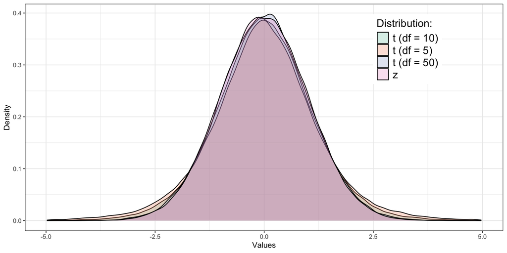

## Critical values

- I’ll assume you all remember critical values from earlier metrics classes
  - If not, ask now!
  - Confidence level (e.g. 0.05 for 95% confidence): $\alpha$
- We construct our CI as:
  $$\begin{gather} CI = \left(\hat{\beta} - t^{1-\frac{\alpha}{2}}_{n-k-1} \times \sqrt{Var(\hat{\beta})},\hspace{3mm} \hat{\beta} + t^{1-\frac{\alpha}{2}}_{n-k-1} \times \sqrt{Var(\hat{\beta})}\right) \end{gather}$$
- At smaller sample sizes, the t distribution has fatter tails
  - This means that we need to be more uncertain about the true value of $\beta$ and the critical value can be quite different

## Critical values for the different distributions

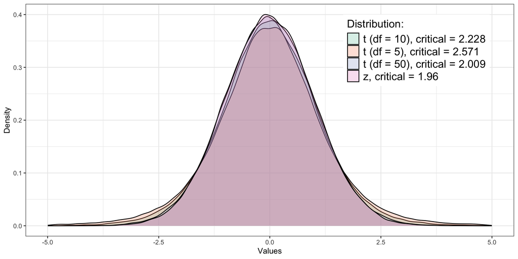

## Understanding the confidence interval

- Let’s go back to our example with the sample of 50
- What, exactly, does the confidence interval represent?
- Suppose we took a bunch of samples of size 50, let’s say 100 of them
  - We would get a bunch of different estimates of $\hat{\beta}$
  - Let’s plot them along with the confidence intervals

## Degrees of freedom: $n - k - 1 = 48$

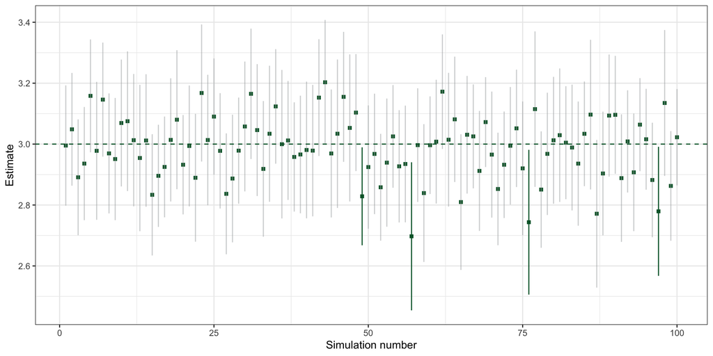

## Confidence intervals

- Confidence intervals are a frequentist idea
  - They are about the probability of the true value being in the interval
- We usually can’t know for sure whether or not the true value is in the interval
  - The probability is only about “averages” over many samples
- We can change our confidence level:
  - $\alpha=0.01$ (confidence level of 99%) gives us a wider interval
  - $\alpha=0.10$ (confidence level of 90%) gives us a narrower interval

## Hypothesis testing

- We can also explicitly test whether or not a coefficient is different from some value
  - What is the most common value we are interested in?
- Zero!
- We can do this with a t-test
  - Null hypothesis ($H_0$): what we assume is true
  - Alternative hypothesis ($H_1$): not the null
- Common example with a regression coefficient:
  - $H_0: \beta = 0$
  - $H_1: \beta \neq 0$
- NOTE: We are testing for the POPULATION parameter, not the sample statistics

## Hypothesis testing

- t-test:
  $$\begin{gather} \hat{t} = \frac{\hat{\beta} - H_0}{SE(\hat{\beta})}, \end{gather}$$

where $SE(\hat{\beta})$ is the standard error of $\hat{\beta}$, or $\sqrt{Var(\hat{\beta})}$. I use $\hat{t}$ here to underline that this comes from our sample statistics.

- We can then compare this to a critical value
  - If $|\hat{t}| > t_{n-k-1}^{1-\frac{\alpha}{2}}$, then we reject the null
  - If $|\hat{t}| < t_{n-k-1}^{1-\frac{\alpha}{2}}$, then we fail to reject the null

## Type 1 and type 2 errors

- Type 1 error: we reject the null when it is true
  - $\alpha$ is the probability of a type 1 error
- Type 2 error: we fail to reject the null when it is false
  - We do not know the probability of a type 2 error

## Interpreting the output

```r
# using feols (from fixest package) instead of lm now
library(fixest)
feols(agemployment ~ log(gnipc) + lfp + log(population) + urbanpop, data = data)
```

```
OLS estimation, Dep. Var.: agemployment
Observations: 1,420
Standard-errors: IID
                  Estimate Std. Error   t value  Pr(>|t|)
(Intercept)     105.201328   2.731881  38.50875 < 2.2e-16 ***
log(gnipc)      -10.112581   0.239763 -42.17745 < 2.2e-16 ***
lfp               0.241674   0.015230  15.86875 < 2.2e-16 ***
log(population)   0.376890   0.129339   2.91398 0.0036246 **
urbanpop         -0.208143   0.016205 -12.84437 < 2.2e-16 ***
---
Signif. codes:  0 '***' 0.001 '**' 0.01 '*' 0.05 '.' 0.1 ' ' 1
RMSE: 7.33605   Adj. R2: 0.834605
```

## Something really nice about fixest (feols)

```r
# using feols instead of lm now
reg1 <- feols(agemployment ~ log(gnipc) + lfp + log(population) + urbanpop, data = data)
reg2 <- feols(servicesemployment ~ log(gnipc) + lfp + log(population) + urbanpop, data = data)
etable(reg1, reg2,
        se.below = TRUE, se.row = FALSE, digits = 3,
        digits.stats = 3, fitstat = c("r2", "ar2", "f", "n")
        )
```

```
                        reg1               reg2
Dependent Var.: agemployment servicesemployment

Constant          105.2***            -7.05**
                   (2.73)             (2.18)
log(gnipc)        -10.1***             7.35***
                   (0.240)            (0.191)
lfp                 0.242***          -0.048***
                   (0.015)            (0.012)
log(population)     0.377**           -0.873***
                   (0.129)            (0.103)
urbanpop           -0.208***           0.267***
                   (0.016)            (0.013)
_______________ ____________ __________________
R2                     0.835              0.849
Adj. R2                0.835              0.849
F-test               1,791.1            1,995.2
Observations           1,420              1,420
---
Signif. codes: 0 '***' 0.001 '**' 0.01 '*' 0.05 '.' 0.1 ' ' 1
```

## Some important statistics

$$\begin{gather} \bar{R}^2 = 1 - (1 - R^2)\frac{n-1}{n-k-1} \end{gather}$$

## F tests

- The F distribution is important in linear regression
  - It is the ratio of two chi-squared distributions, so it has two different degrees of freedom
  - We sometimes refer to these as the “numerator” and “denominator” degrees of freedom
  - An F statistic is always positive
- In the previous regression, the F at the bottom is a test of whether or not all of the coefficients are equal to zero
  - This is a joint test of the coefficients
  - The null hypothesis is that *all* of the coefficients are equal to zero
  - The alternative hypothesis is that *at least one* of the coefficients is not equal to zero
- In practice, we usually just use the p-value because of the fact that critical values of F distributions can be quite different depending on the d.f.

## F distributions with different degrees of freedom

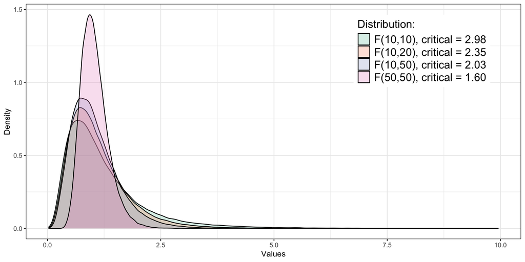

## F distributions and hypothesis testing

- t-tests are the workhorse for inference on a *single* coefficient
- But what if we want to test multiple coefficients at once?
  - F-tests
- Consider the following regression:
  $$\begin{gather} y_i = \beta_0 + \beta_1x_{1,i} + \beta_2x_{2,i} + \beta_3x_{3,i} + \epsilon_i \end{gather}$$
- How might we think about testing whether $\beta_1 = \beta_2 = 0$?

## F distributions and hypothesis testing

$$\begin{gather} y_i = \beta_0 + \beta_1x_{1,i} + \beta_2x_{2,i} + \beta_3x_{3,i} + \epsilon_i \end{gather}$$
- If we assume $\beta_1 = \beta_2 = 0$, that is the same as estimating:
$$\begin{gather} y_i = \tilde{\beta}_0 + \tilde{\beta}_3x_{3,i} + \tilde{\epsilon}_i \end{gather}$$

- Intuitively, we want to know whether the first specification is “better” than the second. We can calculate the estimated variance of the residuals in each specification:
  $$\begin{gather}\hat{\sigma}^2 = \sum_1^n(y_i - \hat{y}_i)^2 \\
  \tilde{\sigma}^2 = \sum_1^n(y_i - \tilde{y}_i)^2 \end{gather}$$

## F distributions and hypothesis testing

$$\begin{gather}\hat{\sigma}^2 = \sum_1^n(y_i - \hat{y}_i)^2 \\
\tilde{\sigma}^2 = \sum_1^n(y_i - \tilde{y}_i)^2 \end{gather}$$

- We can then calculate the F statistic:

$$\begin{gather} F = \frac{(\tilde{\sigma}^2 - \hat{\sigma}^2)/q}{\hat{\sigma}^2/(n - k - 1)}, \end{gather}$$

where $q$ is the number of restrictions we are testing. In this case, $q = 2$ (two restricted coefficients).

## F distributions and hypothesis testing

$$\begin{gather} F = \frac{(\tilde{\sigma}^2 - \hat{\sigma}^2)/q}{\hat{\sigma}^2/(n - k - 1)} \end{gather}$$

- The numerator ($(\tilde{\sigma}^2 - \hat{\sigma}^2)/q$) is distributed as $\chi^2$ with $q$ degrees of freedom
- The denominator ($\hat{\sigma}^2/(n - k - 1)$) is distributed as $\chi^2$ with $n-k-1$ degrees of freedom
- Their ratio is distributed as F with $q$ and $n-k-1$ degrees of freedom:

$$\begin{gather} F = \frac{(\tilde{\sigma}^2 - \hat{\sigma}^2)/q}{\hat{\sigma}^2/(n - k - 1)} \sim F(q,n-k-1) \end{gather}$$

- Now you see why they are sometimes referred to as “numerator” and “denominator” degrees of freedom!

## F-test by hand - note the relationship with the t-test for a single coefficient!

```r
# full specification
full <- feols(agemployment ~ log(gnipc) + lfp + log(population) + urbanpop, data = data)
# restricted
restricted <- feols(agemployment ~ log(gnipc) + lfp + urbanpop, data = data)
sigma_full <- sum((full$resid)^2) # sigma for full
sigma_restricted <- sum((restricted$resid)^2) # sigma for restricted
((sigma_restricted - sigma_full)/1)/(sigma_full/(full$nobs - 4 - 1)) # calculate F statistic
```

```
[1] 8.49128
```

## F-test by hand - note the relationship with the t-test for a single coefficient!

```r
full
```

```
OLS estimation, Dep. Var.: agemployment
Observations: 1,420
Standard-errors: IID
                  Estimate Std. Error   t value  Pr(>|t|)
(Intercept)     105.201328   2.731881  38.50875 < 2.2e-16 ***
log(gnipc)      -10.112581   0.239763 -42.17745 < 2.2e-16 ***
lfp               0.241674   0.015230  15.86875 < 2.2e-16 ***
log(population)   0.376890   0.129339   2.91398 0.0036246 **
urbanpop         -0.208143   0.016205 -12.84437 < 2.2e-16 ***
---
Signif. codes:  0 '***' 0.001 '**' 0.01 '*' 0.05 '.' 0.1 ' ' 1
RMSE: 7.33605   Adj. R2: 0.834605
```

- For a *single* coefficient, $F = t^2$!

# Alternative standard errors

## Sandwich estimators

- There is a broad class of estimators that are called “sandwich estimators” because of their form
- The baseline *heteroskedasticity-consistent* standard errors are:
  $$\begin{gather} Var(\hat{\boldsymbol{\beta}}) = (\mathbf{X}' \mathbf{X})^{-1} \left( \sum_i^n X_i X_i' \sigma_i^2 \right) (\mathbf{X}' \mathbf{X})^{-1} \end{gather}$$
- Of course we don’t know $\sigma_i^2$, so we calculate a feasible estimate using the residuals:
  $$\begin{gather} Var(\hat{\boldsymbol{\beta}})^{HC0} = (\mathbf{X}' \mathbf{X})^{-1} \left( \sum_i^n X_i X_i' \hat{e_i}^2 \right) (\mathbf{X}' \mathbf{X})^{-1} \end{gather}$$
- This is sometimes referred to as $HC0$ standard errors, or **Eicker-White** standard errors
  - We actually don’t use these much!

## Bias in HC0

- But there’s a problem: it turns out that $\sum_i\hat{e_i}^2$ is a biased estimator for $\sigma_i^2$!
  - It’s biased towards zero (“attenuated”) so the standard errors are a bit too small
- The next step is to use a scaling factor to “correct” the standard errors
  - This is sometimes referred to as $HC1$ standard errors

$$\begin{gather} Var(\hat{\boldsymbol{\beta}})^{HC1} = \frac{n}{n-k-1}(\mathbf{X}' \mathbf{X})^{-1} \left( \sum_i^n X_i X_i' \hat{e_i}^2 \right) (\mathbf{X}' \mathbf{X})^{-1} \end{gather}$$

- This is a bit ad hoc, but is generally preferred (Hanson, 2022).
  - **This is currently the default in Stata (with the option *robust*)**
  - **With fixest in R, this is what you get with `vcov = "hetero"`**

## Two more…

- To confuse you more, there are two additional alternatives:
  $$\begin{gather} Var(\hat{\boldsymbol{\beta}})^{HC2} = (\mathbf{X}' \mathbf{X})^{-1} \left( \sum_i^n (1 - h_{ii})^{-1} X_i X_i' \hat{e_i}^2 \right) (\mathbf{X}' \mathbf{X})^{-1} \\
  Var(\hat{\boldsymbol{\beta}})^{HC3} = (\mathbf{X}' \mathbf{X})^{-1} \left( \sum_i^n (1 - h_{ii})^{-2} X_i X_i' \hat{e_i}^2 \right) (\mathbf{X}' \mathbf{X})^{-1} \end{gather}$$
- $h_{ii}$ has to do with a diagonal element of an orthogonal projection matrix. We’re going to ignore this for now.
- These are sometimes referred to as $HC2$ and $HC3$ standard errors (and they may actually perform better!)
- When I refer to HC standard errors, I will be talking about $HC1$ unless I say otherwise

## Clustering

- One of the most common types of heteroskedasticity is clustering
  - This is when the error term is correlated within groups
  - For example, if we have data on students within schools, the error term for students in the same school is likely to be correlated
- Let $K$ denote the number of clusters and $k$ a specific cluster
  - We can then calculate the cluster-robust variance estimator as:

$$\begin{gather} Var(\hat{\boldsymbol{\beta}})^{cluster} = (\mathbf{X}' \mathbf{X})^{-1} \sum_{k=1}^K \left(\sum_{i=1}^{n_k} X_{ik} \hat{e}_{ik} \right) \left(\sum_{l=1}^{n_k} X_{lk} \hat{e}_{lk} \right)' (\mathbf{X}' \mathbf{X})^{-1} \end{gather}$$

- One nice thing: this is also robust to heteroskedasticity in general! (but clustering is also a form of heteroskedasticity)

## Clustering

- The basic intuition is that the more correlated the observations in a cluster is, the larger the variance of the estimated coefficients
  - You can actually show this with some algebra and some assumptions
  - This *intra-cluster correlation* is often referred to as $\rho$

## Clustering

- Suppose you have no clustering at all. Then your effective sample size is $n$.
- Suppose all of your observations are perfectly correlated with the cluster ($\rho=1$). Then your effective sample size is just the number of clusters.
- Of course, neither assumption is likely to ever be true. We are usually somewhere in between, but hopefully this helps with intuition.
- All of these alternative standard error (variance) calculations only affect the standard errors. **Coefficients do not change.**

## Clustering and standard errors

```r
reg1 <- feols(agemployment ~ log(gnipc) + lfp + log(population) + urbanpop, data = data, vcov = "iid") # homoskedasticity
reg2 <- feols(agemployment ~ log(gnipc) + lfp + log(population) + urbanpop, data = data, vcov = "hetero") # HC1 correction
reg3 <- feols(agemployment ~ log(gnipc) + lfp + log(population) + urbanpop, data = data, cluster = "country") # clustering
etable(reg1, reg2, reg3,
       headers = c("iid", "HC1", "cluster"), depvar = FALSE,
        se.below = TRUE, se.row = FALSE,
        digits = 3, digits.stats = 3, fitstat = c("wald", "n")
        )
```

```
                           reg1       reg2       reg3
                            iid        HC1    cluster

Constant             105.2***   105.2***   105.2***
                      (2.73)     (3.15)     (9.40)
log(gnipc)           -10.1***   -10.1***   -10.1***
                      (0.240)    (0.243)    (0.713)
lfp                    0.242***   0.242***   0.242***
                      (0.015)    (0.016)    (0.041)
log(population)        0.377**    0.377**    0.377
                      (0.129)    (0.140)    (0.462)
urbanpop              -0.208***  -0.208***  -0.208***
                      (0.016)    (0.016)    (0.047)
____________________ __________ __________ __________
Wald (joint nullity)    1,791.1    1,094.1      137.0
Observations              1,420      1,420      1,420
---
Signif. codes: 0 '***' 0.001 '**' 0.01 '*' 0.05 '.' 0.1 ' ' 1
```

## What level do we cluster at?

- This is a hard question to answer in many cases
  - With panel data, we usually cluster at the unit level (e.g. individuals)
  - In the previous example, this was the country level
- Always cluster at the level of randomization
  - If the data is collected using a complex survey design, we cluster at the the “enumeration area” level
- **We do not know the “correct” level at which to cluster except in rare situations.**
- [Cameron and Miller (2015)](https://jhr.uwpress.org/content/50/2/317.short) is a nice paper on this topic

## Some complications

- What if the size of clusters is quite different?
  - Variance is calculated as the sum of errors within clusters, so different cluster sizes means differences in variance
  - This is basically heteroskedasticity
  - The key takeaway from this is that smaller samples may show bias (finite-sample bias)
  - Which leads to…
- What if $K$ is small, i.e. we have relatively few clusters?
  - One way to think about it is that our effective sample size is closer to $K$ than $n$
  - Unless we are willing to assume normality of the error term (which we already know we can’t), small samples can be problematic
  - What to do? We will return to this in the next section on bootstrapping.

## Before moving on… the regression “assumptions”

Have you seen these before?

1. **Linearity:** the relationship between the outcome and covariates is linear
2. **Full rank:** the matrix $\mathbf{X}$ has full rank
   - Another way to say this: no perfect collinearity
3. **Exogeneity:** the error term is uncorrelated with the covariates
4. **Homoskedasticity:** the variance of the error term is constant
5. **Normality:** the error term is normally distributed

## Linearity

1. **Linearity:** the relationship between the outcome and covariates is linear
- Regardless of the “true” relationship, OLS will always give you the best linear approximation

## Full rank of $\mathbf{X}$

2. **Full rank:** the matrix $\mathbf{X}$ has full rank, or no perfect collinearity
- This is required to estimate the regression.
- If there is perfect collinearity, then the matrix $\mathbf{X}'\mathbf{X}$ is not invertible
- Stata and R will automatically drop variables to make this happen

## Full rank of $\mathbf{X}$

3. **Exogeneity:** the error term is uncorrelated with the covariates
- Ignore this for now. We’ll come back to it.

## Homoskedasticity

4. **Homoskedasticity:** the variance of the error term is constant
- Obviously not required! We’ve already talked about this. There are corrections.

## Normality

5. **Normality:** the error term is normally distributed
   - This is not required for OLS!
   - The only time this is important is with small samples.
     - With small samples, we need to assume normality to do hypothesis testing.
   - With large samples, we can use the central limit theorem to get around non-normality.
     - A note: the more “non-normal” the error term is, the larger the sample size we need for appropriate inferences.

# Resampling methods

## Bootstrapping (resampling)

- It turns out that there is an alternative to calculting standard errors using formulas
  - It’s called bootstrapping
  - It’s a resampling method
    - I’ll abuse terminology and will generally refer to all of these as “bootstrapping”
- Bootstrapping originated with Efron (1970)
  - Lots of work since then
  - There are many different types of bootstrapping

## Resampling *with replacement*

- Bootstrapping is about sampling from your data
  - Something you might not be used to: it is sampling *with replacement*
- Imagine a vector with 10 elements: $\{1,2,3,4,5,6,7,8,9,10\}$
  - Imagine we sample a randomly selected element. Let’s say we get 5.
  - Now, we want to take another randomly selected element. The question: do we put the 5 back in or not?
  - With replacement: put the 5 back in
  - Without replacement: don’t put the 5 back in
- Bootstrapping is *with replacement*
  - Put the 5 back in!

## Resampling 10 observations *with replacement*

- The key is that we sample rows – i.e. observations. We do not sample columns. We take an observation and all its values.
- The original sample

```
# A tibble: 10 × 2
   country  year
   <chr>   <dbl>
 1 AUT      2003
 2 BGD      2003
 3 BEL      2003
 4 BEN      2003
 5 BRA      2003
 6 BGR      2003
 7 KHM      2003
 8 CAN      2003
 9 CHL      2003
10 COL      2003
```

- The bootstrapped sample

```
# A tibble: 10 × 2
   country  year
   <chr>   <dbl>
 1 AUT      2003
 2 CAN      2003
 3 BGR      2003
 4 KHM      2003
 5 CHL      2003
 6 CHL      2003
 7 AUT      2003
 8 CAN      2003
 9 KHM      2003
10 CAN      2003
```

## Bootstrapping to estimate variance

- Suppose we are interested in the variance of a coefficient estimate, $\hat{\beta}_1$
  - We can use bootstrapping to estimate the variance of $\hat{\beta}_1$
  - Keeping it simple, here is our regression:

$$\begin{gather} y_i = \beta_0 + \beta_1x_{1,i} + \beta_2x_{2,i} + \beta_3x_{3,i} + \beta_4x_{4,i} + \epsilon_i \end{gather}$$

```r
feols(agemployment ~ log(gnipc) + lfp + log(population) + urbanpop, data = data)
```

```
OLS estimation, Dep. Var.: agemployment
Observations: 1,420
Standard-errors: IID
                  Estimate Std. Error   t value  Pr(>|t|)
(Intercept)     105.201328   2.731881  38.50875 < 2.2e-16 ***
log(gnipc)      -10.112581   0.239763 -42.17745 < 2.2e-16 ***
lfp               0.241674   0.015230  15.86875 < 2.2e-16 ***
log(population)   0.376890   0.129339   2.91398 0.0036246 **
urbanpop         -0.208143   0.016205 -12.84437 < 2.2e-16 ***
---
Signif. codes:  0 '***' 0.001 '**' 0.01 '*' 0.05 '.' 0.1 ' ' 1
RMSE: 7.33605   Adj. R2: 0.834605
```

## Bootstrapping to estimate variance

- Imagine a single bootstrap sample, which we will denote with $b$
  - We are going to call the estimate we are interested in $\hat{\theta}_b$ (which in this case is a coefficient)
- Let’s calculate the variance using our bootstrap as follows:

$$\begin{gather} Var(\hat{\theta}) = \frac{1}{B-1} \sum_{b=1}^B (\hat{\theta}_{b} - \bar{\theta})^2, \end{gather}$$
where
$$\begin{gather} \bar{\theta} = \frac{1}{B} \sum_{b=1}^B \hat{\theta}_{b} \end{gather}$$

## Bootstrapping to estimate variance

- In words:
  - We take a bunch of bootstrap samples (more is better, but we’ll do 1,000)
  - We estimate the regression in each bootstrap sample and save the coefficient we are interested in
  - After all 1,000 bootstrap samples, we calculate the variance as the mean (almost) of the squared differences between each bootstrap estimate and the mean of the bootstrap estimates

## Bootstrapping to estimate variance

```r
# empty container to hold the estimates
bootvec <- c()
# 1000 samples
for (b in 1:1000){
  # take a sample with replacement (same size as data)
  sample <- data[sample(1:nrow(data), nrow(data), replace = TRUE),]
  # estimate regression
  reg <- feols(agemployment ~ log(gnipc) + lfp + log(population) + urbanpop, data = sample)
  # add coefficient to vector
  bootvec <- c(bootvec, reg$coefficients[2])
}
# find variance
var <- sum((bootvec - mean(bootvec))^2)/999
# estimated standard error is the square root
sqrt(var)
```

```
[1] 0.2374529
```

The original estimates:

```
             Estimate Std. Error
(Intercept) 105.20133  2.7318815
log(gnipc)  -10.11258  0.2397627
```

## Bootstrapping to estimate variance

- The estimated standard error is the square root of the variance, and it is quite close to the standard error we got from the regression
- In reality, there’s no reason to do this for a single coefficient like this
  - But it’s a good way to understand the intuition behind bootstrapping
  - Bootstrapping works by treating the sample *as if it were the population*
- Where this becomes really powerful is where there is no closed-form solution for the variance
  - For example, what if we wanted to calculate $\frac{\hat{\beta}_2}{\hat{\beta}_3}$?
  - To be clear, this is a non-sense example, but it’s just to illustrate the point

## Our non-sense example

```r
# empty container to hold the estimates
bootvec <- c()
# 1000 samples
for (b in 1:1000){
  # take a sample with replacement (same size as data)
  sample <- data[sample(1:nrow(data), nrow(data), replace = TRUE),]
  # estimate regression
  reg <- feols(agemployment ~ log(gnipc) + lfp + log(population) + urbanpop, data = sample)
  # add coefficient to vector
  bootvec <- c(bootvec, reg$coefficients[2]/reg$coefficients[3])
}
# find variance
var <- sum((bootvec - mean(bootvec))^2)/999
# estimated standard error is the square root
sqrt(var)
```

```
[1] 3.011871
```

## Clustered bootstrap

- There’s a problem with the previous example: we are assuming that the observations are independent
- What if we think there is clustering?
  - We can use a clustered bootstrap (block bootstrap), where we randomly sample CLUSTERS, not observations
  - In this case, clusters are countries, so we will randomly sample countries

## Clustered bootstrap

```r
feols(agemployment ~ log(gnipc) + lfp + log(population) + urbanpop, data = data, cluster = "country")
```

```
OLS estimation, Dep. Var.: agemployment
Observations: 1,420
Standard-errors: Clustered (country)
                  Estimate Std. Error    t value   Pr(>|t|)
(Intercept)     105.201328   9.400891  11.190570  < 2.2e-16 ***
log(gnipc)      -10.112581   0.713338 -14.176414  < 2.2e-16 ***
lfp               0.241674   0.041227   5.861974 3.0986e-08 ***
log(population)   0.376890   0.462084   0.815631 4.1609e-01
urbanpop         -0.208143   0.047444  -4.387083 2.2344e-05 ***
---
Signif. codes:  0 '***' 0.001 '**' 0.01 '*' 0.05 '.' 0.1 ' ' 1
RMSE: 7.33605   Adj. R2: 0.834605
```

## Bootstrapping to estimate variance

```r
# empty container to hold the estimates
bootvec <- c()
# get list of countries
countries <- unique(data$country)
# This takes longer to run, so just 500 as an example (try to use more)
for (b in 1:500){
  # take a sample with replacement (same size as data)
  samplecountries <- countries[sample(1:length(countries), length(countries), replace = TRUE)]
  # go through sample countries and get data, appending
  sample <- c()
  for (c in samplecountries){
    sample <- rbind(sample, data %>% filter(data$country==paste0(c)))
  }
  # estimate regression
  reg <- feols(agemployment ~ log(gnipc) + lfp + log(population) + urbanpop, data = sample)
  # add coefficient to vector
  bootvec <- c(bootvec, reg$coefficients[2])
}
# find variance
var <- sum((bootvecsave - mean(bootvecsave))^2)/499
# estimated standard error is the square root
print(paste0("Standard error: ", format(sqrt(var), digits = 3)))
```

```
[1] "Standard error: 0.759"
```

## Using the bootstrap vector for confidence intervals

- We can use our bootstrap vector to calculate confidence intervals
  - We can use the 2.5th and 97.5th percentiles of the bootstrap vector to get a 95% confidence interval:

$$\begin{gather} CI = \left( \hat{\theta}_{\alpha/2}, \hat{\theta}_{1-\alpha/2} \right) \end{gather}$$

## Using the bootstrap vector for confidence intervals

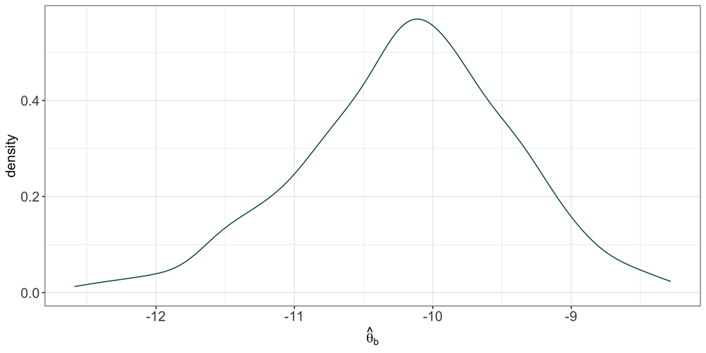

```
[1] "Mean: -10.2"
```

```
[1] "Lower: -11.9"
```

```
[1] "Upper: -8.75"
```

## Non-parametric

- This type of bootstrap is non-parametric
  - That is, we are not assuming anything about the distribution of the data
  - The previous kernel density plot wasn’t normally distributed, it was skewed, etc.
  - This flexibility is one of the main advantages of bootstrapping
- The main downside to bootstrapping is computation
  - The previous example takes about 5 minutes to run on my computer with just 500 samples (and it’s a good computer)
  - More elaborate estimation can take much longer

## An actual example from one of my papers

- Brummund and Merfeld (2022)
  - We want to estimate marginal revenue product of labor (MRPL)
- Here is the specification:

$$\begin{gather}\begin{split} \ln R_{iht} = \alpha_h + I(\textit{Farm}=1)\times(\underset{j}{\Sigma} \beta_{j}\ln \gamma_{jiht} + \frac{1}{2}\underset{j}{\Sigma}\underset{k}{\Sigma}\beta_{jk}\ln\gamma_{jiht} \ln\gamma_{kiht} + \delta C_{iht} \\
+ D_{dt} + \eta_{m}) + \underset{j}{\Sigma} \beta_{j}\ln \gamma_{jiht} + \frac{1}{2}\underset{j}{\Sigma}\underset{k}{\Sigma}\beta_{jk}\ln\gamma_{jiht} \ln\gamma_{kiht} + \delta C_{iht} + D_{dt} + \eta_{m} \\
+ I(\textit{Farm}=1) + \varepsilon_{iht} \end{split}\end{gather}$$

## An actual example from one of my papers

- This is what we need to estimate, using coefficients from the previous equation:
  $$\begin{gather} \frac{\partial R^f}{\partial L^f}=\frac{\hat R_{iht}^f}{L_{iht}^f}\left[\beta_L^f+\beta_{LL}^f \log L_{iht}^f+\beta_{LA}\log A_{iht}+\beta_{LF}\log F_{iht}\right] \\
  \frac{\partial R^{nf}}{\partial L^{nf}}=\frac{\hat R_{iht}^{nf}}{L_{iht}^{nf}}\left[\beta_L^{nf}+\beta_{LL}^{nf}\log L_{iht}^{nf}+\beta_{LC}\log C_{iht}\right] \end{gather}$$
- It’s not possble to get closed-form solutions for the variance of these
  - So what did we do? Bootstrapped!
  - Household panel data, so clustered bootstrap at the household level

## The parametric bootstrap

- There is another type of bootstrap called the parametric bootstrap
  - This is where we assume a distribution for the data
  - We then sample from that distribution
- Essentially, we draw random values from the assumed distribution and add these to the original data
  - We then re-estimate the model
  - We do this many times
  - We then calculate the variance of the coefficient of interest

## The parametric bootstrap

```r
reg1 <- feols(agemployment ~ log(gnipc) + lfp + log(population) + urbanpop, data = data)
ggplot() +
  geom_density(aes(x = reg1$residuals)) +
  theme_bw()
```

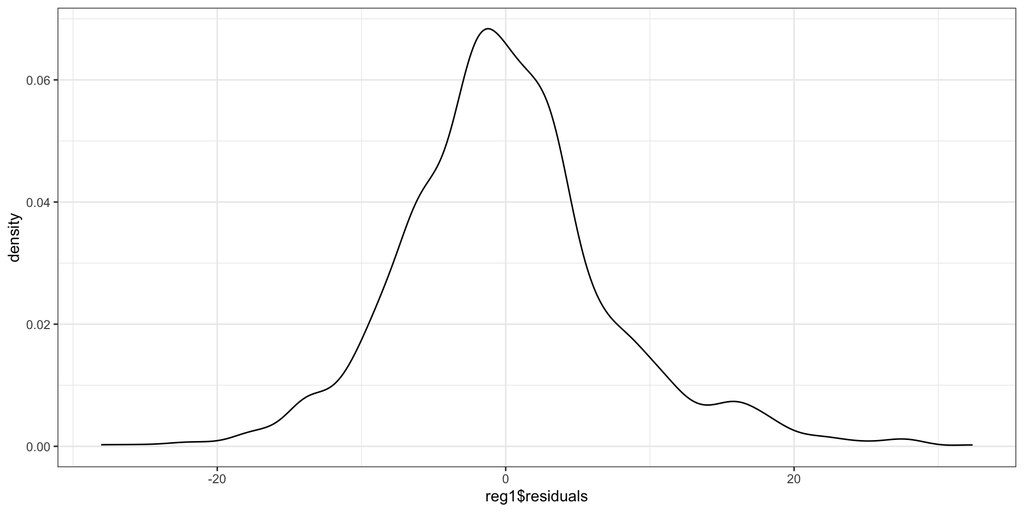

## The parametric bootstrap

- Seems *relatively* normal. Let’s assume a normal distribution!

```r
reg1 <- feols(agemployment ~ log(gnipc) + lfp + log(population) + urbanpop, data = data)
dist <- fitdistr(reg1$residuals, "normal")
dist
```

```
       mean            sd
  6.012568e-13   7.336050e+00
 (1.946786e-01) (1.376585e-01)
```

## The parametric bootstrap

```r
# NOTE: This assume homoskedasticity! (non-parametric bootstrap takes that into)
# Heteroskedasticity would require allowing the variance to change. This is a simple example.
reg1 <- feols(agemployment ~ log(gnipc) + lfp + log(population) + urbanpop, data = data)
dist <- fitdistr(reg1$residuals, "normal")

bootvec <- c()
for (b in 1:1000){
  brep <- data
  # draw from distribution
  brep$agemployment <- brep$agemployment + rnorm(nrow(brep), mean = dist$estimate[1], sd = dist$estimate[2])
  # re-estimate
  reg1 <- feols(agemployment ~ log(gnipc) + lfp + log(population) + urbanpop, data = brep)
  # add to container
  bootvec <- c(bootvec, reg1$coefficients[2])
}
# coefficient was -10.112581
mean(bootvec)
```

```
[1] -10.09777
```

```r
# standard error of homoskedastic model was 0.239763
sd(bootvec)
```

```
[1] 0.2353148
```

## The parametric bootstrap in my work

- The parametric bootstrap is actually integral to some of the work I do with the UN and World Bank on estimating outcomes
- Small area estimation:
  $$y_{isa} = \beta_0 + \beta X_{isa} + \upsilon_{sa} + \epsilon_{isa},$$

where $\upsilon_{isa}$ is a *random effect*. We use a parametric bootstrap to draw from TWO distributions:

- The distribution of the random effect
- The distribution of the error term

## Class exercise

- I’d like you all to try bootstrapping!
  - This is a useful exercise because it lets you practice quite a few important skills in R
- The task:
  - Download `bootstrapdata` from GitHub. This data has just one variable in it: `x`
  - Calculate the 75th percentile of `x` using the function `quantile()`
  - Find the 95% confidence interval for the 75th percentile using the (non-parametric) bootstrap
- I’ll give you 10 minutes to work on this. I’ll be around to help.
  - One way to do this on next slide. But don’t look at it!

## Class exercise solution (one of many)

```r
bootstrapdata <- read_csv("week2files/bootstrapdata.csv")
quantile(bootstrapdata$x, 0.75)
```

```
     75%
2.690306
```

```r
bootvec <- c()
for (b in 1:1000){
  # random sample
  sample <- bootstrapdata$x[sample(1:nrow(bootstrapdata), nrow(bootstrapdata), replace = TRUE)]
  # add quantile to container
  bootvec <- c(bootvec, quantile(sample, 0.75))
}
# 2.5th percentile
quantile(bootvec, 0.025)
```

```
    2.5%
2.490712
```

```r
# 97.5th percentile
quantile(bootvec, 0.975)
```

```
   97.5%
3.012729
```